# Boolean Retrieval

- Nach der Hash Table ist das Boolean eine weitere einfache Methode, die in dieser Veranstaltung behandelt wird.
- In diesem Kontext wird verstanden, dass ein Dokument für eine Abfrage entweder wahr oder falsch ist.
- Es findet keine Gewichtung oder Ranking der Ergebnisse statt.

In diesem Kapitel sollen die ersten gelernten Werkzeuge für die maschinelle Textverarbeitung Anwendung finden. Es wird ein Verfahren für die Indexierung vorgestellt, mit dem Überprüft werden kann, ob Tokens einer Query in einem Dokument enthalten sind oder nicht.

# Inhalt

- Theorie: Aussagenlogik
- Boolean Indexing
- Inverted Boolean Indexing

## Einordnung in die Pipeline

- Bisher haben wir uns viel mit dem Preprocessing (Schritt 2) unserer Textdaten in der Pipeline beschäftigt.
- Zuletzt haben wir mit der Hash Table das erste Indexing-Verfahren kennen gelernt.
- Mit Boolean Indexing lernen wir ein weiteres Indexing-Verfahren kennen.

Dieses Notebok bezieht sich also ausschließlich auf Schritt 3, dem Indexing. Das Verständnis von Schritt 1 und 2 wird vorrausgesetzt.

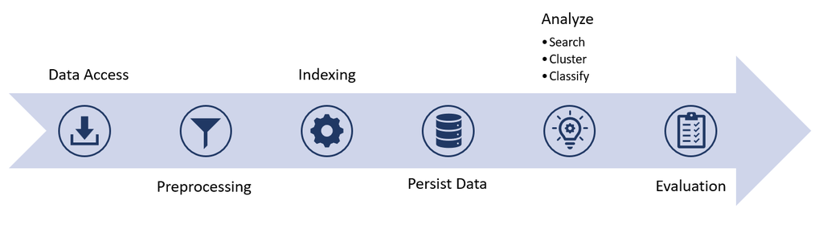

### Kleiner Ausflug in die Aussagenlogik:

Für ein beliebiges Dokument wollen wir ein Information Retrieval System implementieren das überprüft, ob die Wörter *Mittelmeer* **oder** *Pazifik* enthalten sind. In der Aussagenlogik weisen wir beiden Aussagen Variablen zu:

- **A**: für Mittelmeer ist enthalten.
- **B**: für Pazifik ist enthalten.

Die boolsche Aussage $A$ kann dann zwei Zustände annehmen: True oder False. Das Gegenteil von $A$ (also das Wort Mittelmeer ist *nicht* enthalten) wird durch $\neg A$ beschrieben. Hätte $A$ also den Wert `True`, wäre $\neg A$ `False`. Aussagen können auch verknüpft werden und zwar durch Operatoren wie:

- AND: $\wedge$ z.B. $A \wedge B$
- OR: $\vee$ z.B. $A \vee B$

Dabei gilt:

- $A \wedge \neg A = False$
- $A \vee \neg A = True$

Die zuvor beschriebene Aussage, ob die Wörter *Mittelmeer* **oder** *Pazifik* enthalten sind, würde also aussehen wie folgt: $$A \vee B$$

Wir könnten unser Information Retrieval System auch fragen: gib mir alle Dokumente, die *Mittelmeer* enthalten und wenn nicht, dann das Wort *Pazifik*. Dies würde folgendermaßen lauten: $$ A \vee \neg A \wedge B $$

Ein AND-Operator wird dabei stets vor einem OR-Operator evaluiert. Man kann sich dies wie beim "Punkt vor Strich" rechnen vorstellen.

Für $A=True$ und $B=False$ ergibt die Aussage $True$: $$ A \vee \neg A \wedge B = True $$

### Aufgaben Aussagenlogik

**Teil A:** Prüfen Sie selbst einmal für $A=False$ und $B=True$:

1. $ \neg A \wedge B $
2. $ A \wedge B \vee \neg A $
3. $ B \wedge \neg A \vee A $

**Teil B:** Definieren Sie den Term für die Aussage:

1. Das Wörter *Alpen* und *Meer* sollen enthalten sein.
2. Das Wort *Alpen* soll enthalten sein, das Wort *Meer* nicht.
3. Die Wörter *Alpen* und *Fluss* oder das Wort *Meer* sollen enthalten sein.

### Boolean operations with Python

- `AND`: `&`
- `OR`: `|`
- `XOR`: `^`

```python
from glob import glob

import numpy as np
import pandas as pd
from nltk.tokenize import RegexpTokenizer
from nltk.corpus import stopwords
from tqdm.notebook import tqdm
```

```python
# binary operations in Python
one = 0b0101
two = 0b0100

bin(one & two)
```

```
'0b100'
```

```python
# pythonic way with numpy
one = np.array([False, True, True])
two = np.array([False, True, False])
one & two
```

```
array([False,  True, False])
```

```python
one ^ two
```

```
array([False, False,  True])
```

### Daten Vorbereitung

Das kennen Sie ja nun bereits...

```python
tokenizer = RegexpTokenizer("\w+")
stopwords = set(stopwords.words("german"))

def tokenize(text):
    tokens = tokenizer.tokenize(text)
    tokens = [t.lower() for t in tokens]
    tokens = [token for token in tokens if token not in stopwords]
    return tokens
```

```python
# load wikipedia
DIR = "../../data/wikipedia/countries/*.txt"
data = []
filenames = []
for filename in glob(DIR):
    filenames.append(filename.split("\\")[-1].split(".txt")[0])
    with open(filename, "r", encoding="utf8") as f:
        data.append(f.read())
print(f"Loaded {len(filenames)} files.")
```

```
Loaded 235 files.
```

## Boolean Indexing

- Boolean Indexing ist ein weiteres in der Veranstaltung vorgestellte Indexing-Verfahren.
- Das Verfahren überprüft für jedes Token des Vokabulars, ob es im Dokument enthalten ist.
- speichert das berechnete Wissen in einer Tabelle, auch als Matrix bezeichnet.

#### Motivation

- Das Information Retrieval Problem, dass hier gelöst werden soll, beruht auf der Überprüfung, ob ein Token in einem Dokument enthalten ist oder nicht.
- Die Aufgabenstellung könnte also lauten: "Finde alle Dokumente, die das Wort Europa und *nicht* Asien enthalten".
- Ist die Boolean Index Matrix einmal erstellt, können wir mittels der Aussagenlogik die Abfrage durchführen.

#### Funktinsprinzip

Das Funktionsprinzip des Boolean Indexing ist sehr schlicht:

1. Bilde zunächst das Vokabular $v$ des Korpus aus allen seiner Dokumente $n$.
2. Überprüfe für jedes Token $v_i$ des Vokabulars, ob es im Dokument $n_i$ enthalten ist. Wenn ja, vermerke dies mit 1, bzw `True`, oder 0 bzw. `False` wenn nicht.

Als Ergebnis erhalten wir eine Tabelle, die in den Zeilen die Dokumente enthält und in den Spalten die Tokens des Vokabulars. Die Matrix hat also die Größe $v \times d$.

Siehe dazu auch: [Manning et al., Introduction to Information Retrieval, Kapitel 1](https://nlp.stanford.edu/IR-book/pdf/01bool.pdf).

#### Beispiel Implementierung

```python
def create_vocab(data, n):
    tokens = set()
    doc_tokens = []
    for document in data[:n]:
        t = tokenize(document)
        tokens.update(t)
        doc_tokens.append(t)
    tokens = sorted(tokens)
    return tokens, doc_tokens
```

```python
all_tokens, _ = create_vocab(data, len(data))
```

```python
# create binary-term-document incident matrix
def create_index(data, n=230):
    print("Creating vocabulary.")
    tokens, doc_tokens = create_vocab(data, n)

    print("Indexing...")
    index = []
    # tokens = pd.DataFrame(tokens)
    for document in tqdm(doc_tokens):

        # doc_idx = tokens[0].str.contains("|".join(document))
        # index.append(doc_idx)

        # do better
        doc_idx = []
        for token in tokens:
            if token in document:
                doc_idx.append(1)
            else:
                doc_idx.append(0)
        index.append(doc_idx)
    return index, list(tokens)


index, tks = create_index(data, n=30)
```

```
Creating vocabulary.
Indexing...
```

```python
f = ["stimmt", "berechnete"]
d = pd.DataFrame(["test", "stimmt", "berechnete"])
res = np.array(d[0].str.contains("|".join(f)))
res
```

```
array([False,  True,  True])
```

```python
sum(index[0][index[0] == True])
```

[output not shown]

```python
print("Size of vocabulary: ", len(tks))
```

```
Size of vocabulary:  33258
```

```python
index = pd.DataFrame(index, columns=tks, index=filenames[:30])
index.head()
```

|  | 0 | 00 | 000 | 00069 | 001 | 0026 | 003 | 00408 | 00584 | 006944 | ... | ἀνταρκτικός | ἰνδικῆς | ὁ | ⴷⵣⴰⵢⴻⵔ | ⵍⴷⵣⴰⵢⴻⵔ | ⵍⴻⵣⵣⴰⵢⴻⵔ | ⵜⴰⴳⴷⵓⴷⴰ | ⵜⴰⵎⴰⴳⴷⴰⵢⵜ | ⵜⴰⵖⴻⵔⴼⴰⵏⵜ | ⵜⴰⵣⵣⴰⵢⵔⵉⵜ |
| --- | --- | --- | --- | --- | --- | --- | --- | --- | --- | --- | --- | --- | --- | --- | --- | --- | --- | --- | --- | --- | --- |
| afghanistan | 1 | 0 | 1 | 0 | 0 | 0 | 0 | 0 | 0 | 0 | ... | 0 | 0 | 0 | 0 | 0 | 0 | 0 | 0 | 0 | 0 |
| agypten | 1 | 0 | 1 | 0 | 0 | 0 | 0 | 0 | 0 | 1 | ... | 0 | 0 | 0 | 0 | 0 | 0 | 0 | 0 | 0 | 0 |
| albanien | 1 | 0 | 1 | 0 | 0 | 0 | 0 | 0 | 0 | 0 | ... | 0 | 0 | 0 | 0 | 0 | 0 | 0 | 0 | 0 | 0 |
| algerien | 1 | 0 | 1 | 0 | 0 | 0 | 0 | 0 | 0 | 0 | ... | 0 | 0 | 0 | 1 | 1 | 1 | 1 | 1 | 1 | 1 |
| andorra | 1 | 0 | 1 | 0 | 0 | 0 | 0 | 0 | 0 | 0 | ... | 0 | 0 | 0 | 0 | 0 | 0 | 0 | 0 | 0 | 0 |

5 rows × 33258 columns

### Query index

```python
def query(input_query, index):
    res = np.array(index[input_query[0]], dtype=bool)

    for q in input_query[1:]:
        idx = np.array(index[q], dtype=bool)
        res &= idx

    idx_true = np.where(res == True)
    return index.iloc[idx_true][input_query]
```

```python
query(["fluss", "schloss"], index)
```

|  | fluss | schloss |
| --- | --- | --- |
| agypten | 1 | 1 |
| albanien | 1 | 1 |
| andorra | 1 | 1 |
| argentinien | 1 | 1 |
| australien | 1 | 1 |
| bosnien-herzegowina | 1 | 1 |

```python
def and_(q):
    def _and(index, res):
        return res & np.array(index[q], dtype=bool), q
    return _and

def or_(q):
    def _or(index, res):
        return res | np.array(index[q], dtype=bool), q
    return _or

def query2(input_query, index):
    res = np.array(index[input_query[0]], dtype=bool)
    query_words = [input_query[0]]

    for q in input_query[1:]:
        res, word = q(index, res)
        query_words.append(word)

    idx_true = np.where(res == True)
    return index.iloc[idx_true][query_words]

query2(["fluss", or_("badminton"), and_("hamburg")], index)
```

|  | fluss | badminton | hamburg |
| --- | --- | --- | --- |
| argentinien | 1 | 0 | 1 |
| belize | 1 | 0 | 1 |
| birma | 1 | 0 | 1 |

### Probleme

- Indexing bereits bei den wenigen Dokumenten im Beispiel verhältnismäßig sehr langsam.
  - Deshalb habe ich zur Demonstration nur 30 Dokumente genutzt.

#### Warum ist das so?

- Index Matrix ist sehr groß.
- Index Matrix ist *sparse*, also enthält fast nur Nullen.
  - Wie wir wissen kommt über die Hälfte der Tokens nur genau einmal vor. Eine extra Spalte für jedes Token ist daher sehr ineffizient.

```python
print("Index Matrix Form:", index.shape)
print("Index Matrix Größe:", index.size)
```

[output not shown]

Ist das Ergebnis einer Analyse, sollte diese auch immer auf die Qualität ihres Informationsgehaltes überprüft werden. Oftmals entstehen dabei sogenannte *Sparse* -Matrizen, die zum Großteil nur aus Nullen bestehen. Daher ist die Informationsdichte in diesen Fällen sehr gering. Wir überprüfen den Anteil der Nullen in einer Matrix mit der Formel: $$ sparsity = (1 - \frac{nonzero}{size}) * 100 $$

```python
sparsity = (1 - (np.count_nonzero(index) / index.size)) * 100
print(f"Der Anteil Nullen der Index Matrix beträgt {round(sparsity, 2)}%.")
```

```
Der Anteil Nullen der Index Matrix beträgt 92.15%.
```

## Inverted Boolean Indexing

- Der inverted Index soll Problem des einfachen Boolean Indexing entgegen wirken.
- **Idee:** Umkehrung des Prinzips des Boolean Indexing
  - Nun wird zu jedem Token gespeichert, in welchem Dokument es vorkommt
  - **Vorteil:** wir sparen uns das Vermerken ob ein Token *nicht* vorkommt.
  - Vorher mussten wir für jedes vorkommende Token im Korpus für jedes Dokument eine Aussage treffen.

#### Postings List

Das Speichern der Zuordnung eines Tokens zu den Dokumenten in denen es enthalten ist, wird in der Literatur als Posting bezeichnet. Die resultierende Liste als *Posting List*.

```python
def create_inverted_index(data, documents):
    doc_tokens = []
    for document in data:
        t = tokenize(document)
        doc_tokens.append(set(t))

    index = pd.DataFrame()
    for i in tqdm(range(len(documents))):
        name = documents[i]
        tokens = list(doc_tokens[i])
        doc_indices = np.array([tokens, [name] * len(tokens)]).transpose()
        index = index.append(pd.DataFrame(doc_indices))
    index.reset_index()
    index.rename(columns={0: "token", 1: "document"}, inplace=True)
    return index


inverted_index = create_inverted_index(data, filenames)
inverted_index
```

|  | token | document |
| --- | --- | --- |
| 0 | zwei | afghanistan |
| 1 | abgelegene | afghanistan |
| 2 | waali | afghanistan |
| 3 | analphabetenrate | afghanistan |
| 4 | subkontinent | afghanistan |
| ... | ... | ... |
| 1903 | gilt | zypern |
| 1904 | unterschiedlichen | zypern |
| 1905 | abgewickelt | zypern |
| 1906 | pietro | zypern |
| 1907 | fruchtbarste | zypern |

646609 rows × 2 columns

```python
query = "rhein"
inverted_index[inverted_index["token"] == query]
```

|  | token | document |
| --- | --- | --- |
| 4518 | rhein | deutschland |
| 4586 | rhein | frankreich |
| 3692 | rhein | italien |
| 4160 | rhein | kanada |
| 4035 | rhein | liechtenstein |
| 3447 | rhein | niederlande |
| 4743 | rhein | osterreich |
| 5464 | rhein | schweiz |

```python
query = "rhein"
list(inverted_index[inverted_index["token"] == query]["document"])
```

```
['deutschland',
 'frankreich',
 'italien',
 'kanada',
 'liechtenstein',
 'niederlande',
 'osterreich',
 'schweiz']
```

## Aufgabe

In dieser Aufgabe sollen die Funktionen für das Information Retrieval, insbesondere Abfragen für den invertierten Index des Boolean Index schreiben. Nutzen Sie dafür die vorgegebenen Dummy-Methoden.

Schreiben Sie Funktionen für:

1. Die AND-Abfrage.
2. Die OR-Abfrage.
3. In welchen Dokumenten kommen die Tokens: meer, gebirge, berge und fluss vor?
4. In welchen Dokumenten kommen die Tokens: ural *oder* buddhismus vor?
5. Welche Tokens kommen in jedem Dokument vor?

```python
def query_and(query, inverted_index):
    # query is a list of tokens
    pass

def query_or(query, inverted_index):
    # query is a list of tokens
    pass
```

### Vergleich

```python
print("Größe der Inverted Index Matrix:", inverted_index.size)
# remember index size: size_vocab * size_doc
old_index_size = len(all_tokens) * len(data)
print("Vergleich der Größe zur bisherigen:", round(inverted_index.size / old_index_size * 100, 2), "%")
```

```
Größe der Inverted Index Matrix: 1293218
Vergleich der Größe zur bisherigen: 3.93 %
```

## Dynamic Indexing

- Bisher gingen wir davon aus, die Gesamtheit aller Dokumente bleibt unverändert.
- Wird ein neues Dokument in den Korpus aufgenommen, ist es nicht im zuvor erstellten Index enthalten.
- Suchanfragen würde also niemals das neue Dokument in der Ergebnismenge enthalten.
- Um nun das neue Dokument hinzuzufügen, müsste der gesamte Index neu erstellt.
- Je nach Algorithmus für die Indexierung und Größe des Korpus schließt dies jedoch eine hohe Rechenkapazität ein.
- In der Praxis wird daher bei jedem neuen Dokument ein sogenannter *Auxillary Index* erstellt, also ein eigener Index der nur die neuen Dokumente beinhaltet.
- Bei einer Abfrage wird die Ergebnismenge aus dem Index der des Auxillary Index hinzugefügt. In regelmäßigen Abständen wird der eigentliche Index auf dem gesamten Korpus inklusive der neuen Dokumente neu gebildet und der *Auxillary Index* zurückgesetzt. Der Abstand sollte abhängig der Frequenz neuer Dokumente und der benötigten Dauer für die Berechnung des Index gewählt werden.

Auf diese Weise wird sichergestellt, dass neue Dokumente sehr zeitnah inkludiert werden können.

Siehe dazu auch: [Manning et al., Introduction to Information Retrieval, Kapitel 4.5](https://nlp.stanford.edu/IR-book/pdf/04const.pdf)

## Boolean Indexing Zusammenfassung

- Indexing Methode
- basiert auf boolscher Aussagenlogik
- einfach
- ermöglicht:
  - Abfragen ob Token enthalten ist oder nicht.
  - Abfragen sind mittels Aussagenlogik verknüpfbar.

### Probleme

- Kostenineffizient
  - Performance
  - Speicher
- Verbesserung: Inverted Index
- Es ist nicht möglich die abgefragten Dokumente nach Relevanz zu sortieren.